# Trabalho final MAE4000

Primeiro vamos carregar os pacotes desejados:

```r
library("prophet")
```

Uma vez com os pacotes carregados, podemos agora carregar e plotar os dados desejados:

```r
weekly_dados = dados %>% mutate(date=ymd(date)) %>% pad() %>%
  fill(`USGG2YR Index`, `USGG5YR Index`, `USGG10YR Index`, `USGG30YR Index`, .direction=c("down")) %>%
  mutate(weekday=weekdays(date, abbreviate = TRUE)) %>% filter(weekday=='Sex'|weekday=='Fri') %>%
  select(-weekday)
```

```
pad applied on the interval: day
```

Os dados consistêm de alguns vértices da curva de juros nominal dos Estados Unidos. Os vérties do juros nominal de cinco (USGG5YR) e dez (USGG10YR) anos possuem observações desde 1970, já os vértices de dois (USGG2YR) e 30 (USGG30YR) anos começam em 1977.

```r
head(weekly_dados)
```

[output not shown]

[output not shown]

No código abaixo, podemos ver o gráfico dos vértices ao longo do tempo:

ATENÇÃO, CHECAR DADOS PARA O JUROS DE 2 E 30 ANOS. ESTÃO ESTRANHOS!!

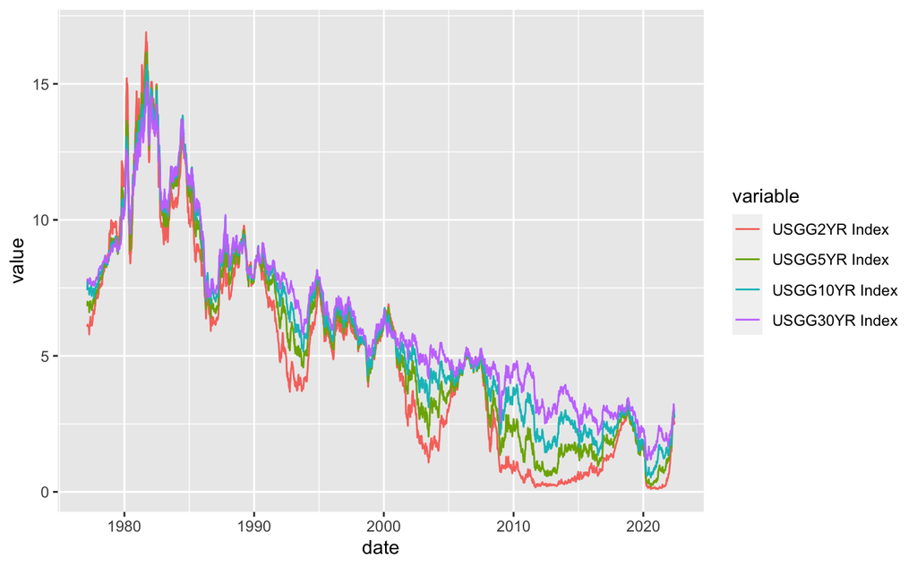

No que se segue, analisaremos o véritce de dez anos.

Começamos nossa análise testando a hipótese de estacionariedade da série em questão. Para tanto, usaremos a definição de Shumway e Stoffer (2016) que caracteriza um processo estacionário da seguinte forma:

> > 1. A função de média do processo não depende de $t$
> > 2. A função de autocovariância do processo depende do tempo somente através da diferença de $|s - t|$

A inspeção visual da série em questão parece indicar que a média da série varia no tempo. Apesar disso, usaremos dois testes de hipótese para identificar raiz unitária no processo, sendo eles o deste de Dickey-Fuller e o teste de Phillips–Perron.

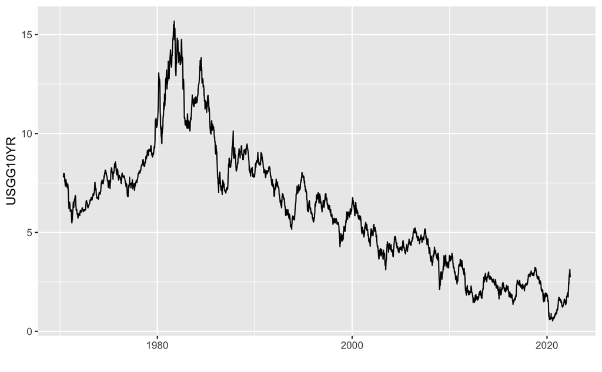

Como podemos ver, ambos os testes não rejeitam a hipótese nula de raiz unitária, portando precisaremos aplicar alguma trasformação nos dados.

```r
adf.test(target_data %>% select(USGG10YR) %>% as.ts())
```

```
    Augmented Dickey-Fuller Test

data:  target_data %>% select(USGG10YR) %>% as.ts()
Dickey-Fuller = -2.5705, Lag order = 13, p-value = 0.3368
alternative hypothesis: stationary
```

```r
PP.test(target_data %>% select(USGG10YR) %>% as.ts())
```

```
    Phillips-Perron Unit Root Test

data:  target_data %>% select(USGG10YR) %>% as.ts()
Dickey-Fuller = -2.5755, Truncation lag parameter = 9, p-value = 0.3347
```

Uma alternativa é aplicar a primeira diferença na série. Podemos notar que ao aplicarmos a primeira diferença, ambos os testes rejeitam a hipótese de raiz unitária do processo diferenciado. Deste modo, seguiremos a análise com o processo em primeira diferença.

```r
adf.test(target_data %>% select(USGG10YR) %>% as.ts() %>% diff())
```

```
    Augmented Dickey-Fuller Test

data:  target_data %>% select(USGG10YR) %>% as.ts() %>% diff()
Dickey-Fuller = -14.177, Lag order = 13, p-value = 0.01
alternative hypothesis: stationary
```

```r
PP.test(target_data %>% select(USGG10YR) %>% as.ts() %>% diff())
```

```
    Phillips-Perron Unit Root Test

data:  target_data %>% select(USGG10YR) %>% as.ts() %>% diff()
Dickey-Fuller = -51.179, Truncation lag parameter = 9, p-value = 0.01
```

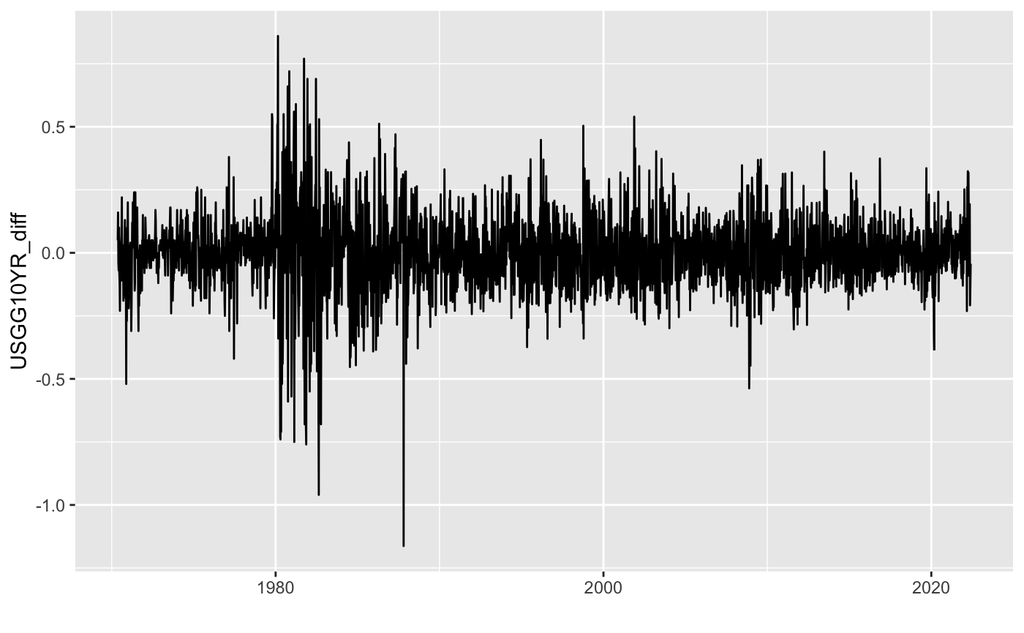

Como primeira forma de identificar o modelo ideal para a série do juros de 10 anos, seguiremos Shumway e Stoffer (2016) e usaremos a função de autocorrelação (ACF) e autocorrelação parcial (PACF) para identificar os parâmetros de um modelo ARMA(p,q).

(NÃO ESTOU SEGURO DESSA PARTE)

Podemos notar que ambas ACF e PACF indicam que o modelo ARMA(4,0) pode ser um bom candidato para modelar o processo gerador de dados.

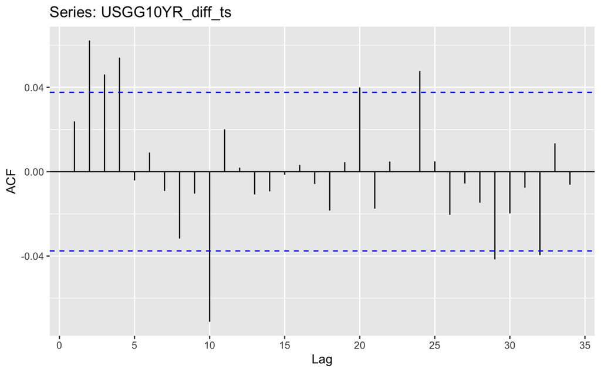

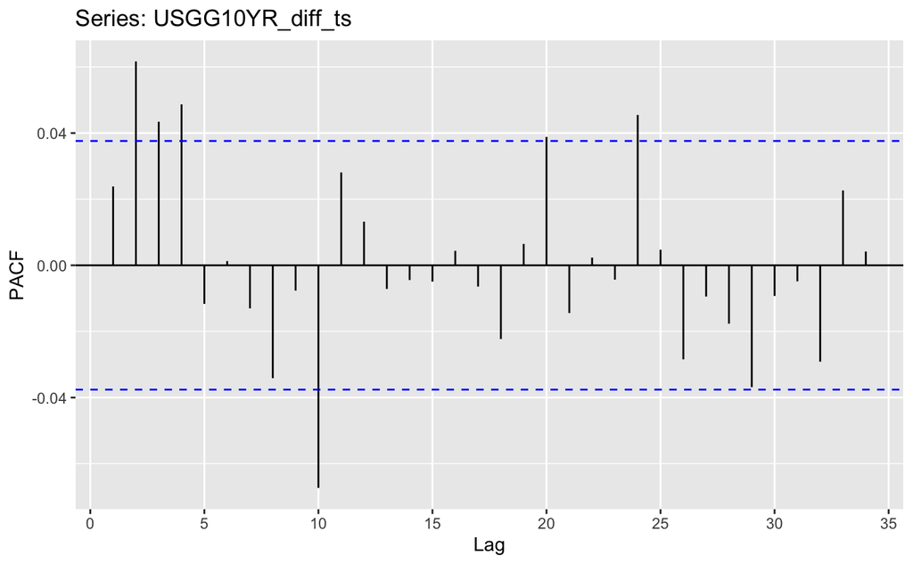

Notamos que para o critério AIC, o modelo escolhido é um ARIMA(4, 0, 4), já para o critério BIC o modelo escolhido é o ARMA(1, 0, 1). Estimaremos os dois modelos e continuaremos a análise a partir deles.

Como terceira forma de escolher o modelo ARMA que melhor se ajusta aos dados, utilizamos a função “auto.arima” do pacote “forecast”. Esta função retorna o melhor modelo ARIMA de acordo com o critério de informação disponível. Notamos que o modelo escolhido é consistente com o critério AIC feito anteriormente, um ARIMA(4,0,4).

[output not shown]

[output cut: 6 more lines]

```r
information_df

min(information_df$AIC)
```

```
[1] -2492.231
```

```r
min(information_df$BIC)
```

```
[1] -2452.372
```

```r
auto_arima <- auto.arima(y = USGG10YR_diff_ts,
                         max.p = 10,
                         max.q = 10)


summary(auto_arima)
```

```
Series: USGG10YR_diff_ts
ARIMA(4,0,4) with zero mean

Coefficients:
         ar1     ar2     ar3      ar4      ma1      ma2      ma3     ma4
      0.1629  0.6203  0.0492  -0.8644  -0.1435  -0.6016  -0.0499  0.8952
s.e.  0.0670  0.0708  0.0706   0.0671   0.0607   0.0636   0.0622  0.0598

sigma^2 = 0.02329:  log likelihood = 1255.94
AIC=-2493.89   AICc=-2493.82   BIC=-2440.73

Training set error measures:
                       ME      RMSE       MAE MPE MAPE      MASE         ACF1
Training set -0.001742654 0.1523696 0.1085135 NaN  Inf 0.7116133 -0.004110331
```

Uma vez com os modelos em mãos, avaliaremos abaixo os modelos ajustados, isto é, avaliaremos as estatísticas de ajuste de modelos bem como o resíduo destes. Para fins de simplificação, chamaremos o modelo ARIMA(4, 1, 4) de modelo A e o modelo ARIMA (1, 1, 1) de modelo B.

Notamos que tanto em termos de log-verossimilhança quanto AIC, o modelo A tem o melhor ajuste. Além disso, ambos os resíduos apresentam problemas. Os resíduos de ambas as séries rejeitam fortemente a hipótese nula de normalidade dos dados. Outro ponto de atenção é que ambos os resíduos apresentam lags significativos na ACF.

```r
summary(arima_aic)
```

```
Call:
arima(x = USGG10YR_diff_ts, order = c(4, 0, 4))

Coefficients:
         ar1     ar2     ar3      ar4      ma1      ma2      ma3     ma4  intercept
      0.1619  0.6198  0.0510  -0.8642  -0.1425  -0.6010  -0.0512  0.8951    -0.0018
s.e.  0.0748  0.0729  0.0758   0.0720   0.0680   0.0653   0.0659  0.0640     0.0031

sigma^2 estimated as 0.02321:  log likelihood = 1256.12,  aic = -2492.23

Training set error measures:
                        ME      RMSE       MAE MPE MAPE      MASE         ACF1
Training set -3.418806e-05 0.1523603 0.1084871 NaN  Inf 0.7114401 -0.004136754
```

```r
shapiro.test(resid_aic$AIC_resid)
```

```
    Shapiro-Wilk normality test

data:  resid_aic$AIC_resid
W = 0.94968, p-value < 2.2e-16
```

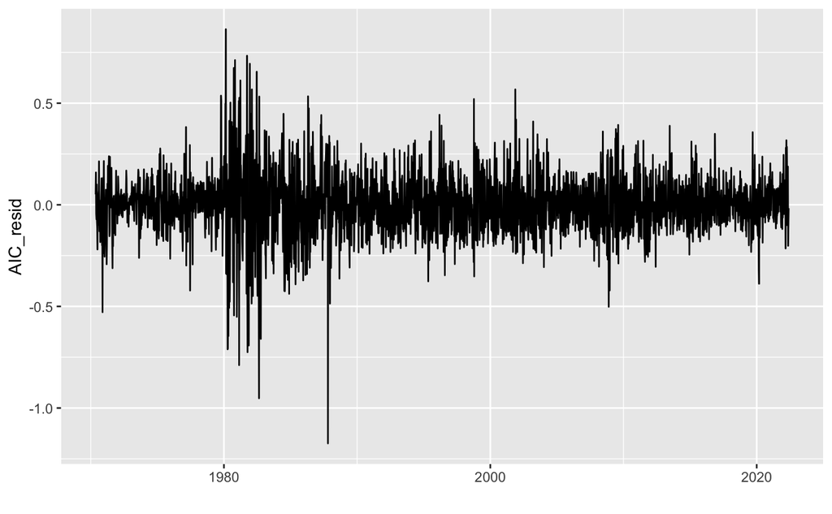

```r
ggplot(resid_aic, aes(x=date, y=AIC_resid)) + geom_line() + xlab("")
```

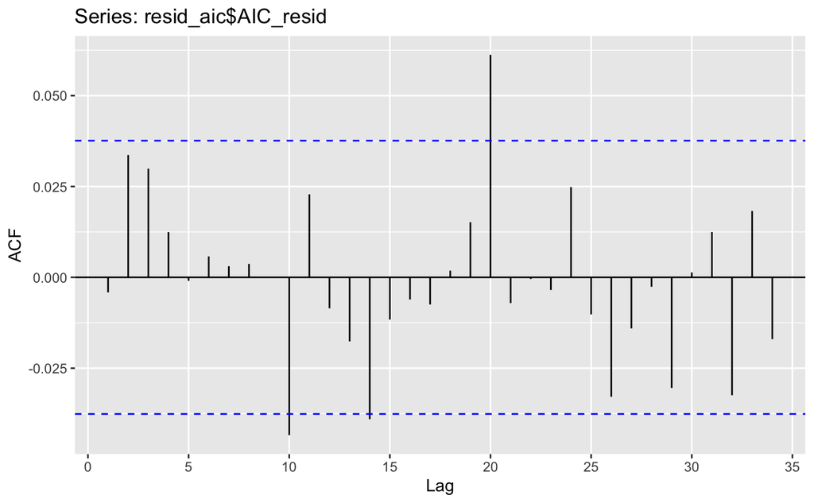

```r
ggAcf(resid_aic$AIC_resid)
```

```r
summary(arima_bic)
```

```
Call:
arima(x = USGG10YR_diff_ts, order = c(1, 0, 1))

Coefficients:
         ar1      ma1  intercept
      0.7200  -0.6727    -0.0019
s.e.  0.0851   0.0898     0.0034

sigma^2 estimated as 0.02346:  log likelihood = 1242,  aic = -2476

Training set error measures:
                       ME      RMSE       MAE MPE MAPE      MASE        ACF1
Training set 6.826162e-05 0.1531664 0.1085509 NaN  Inf 0.7118587 -0.02860198
```

```r
shapiro.test(resid_bic$BIC_resid)
```

```
    Shapiro-Wilk normality test

data:  resid_bic$BIC_resid
W = 0.9465, p-value < 2.2e-16
```

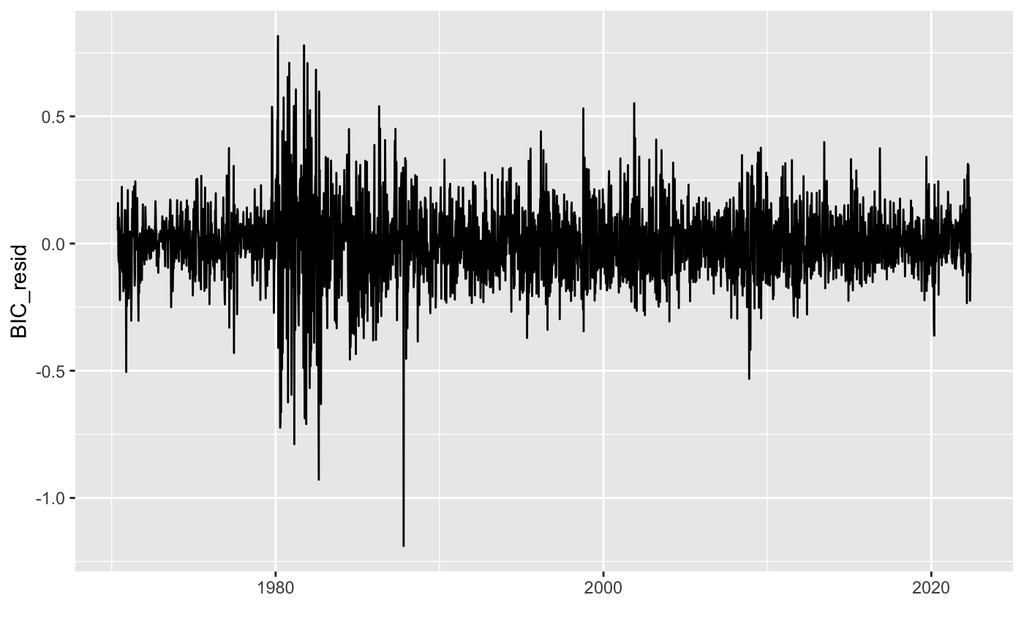

```r
ggplot(resid_bic, aes(x=date, y=BIC_resid)) + geom_line() + xlab("")
```

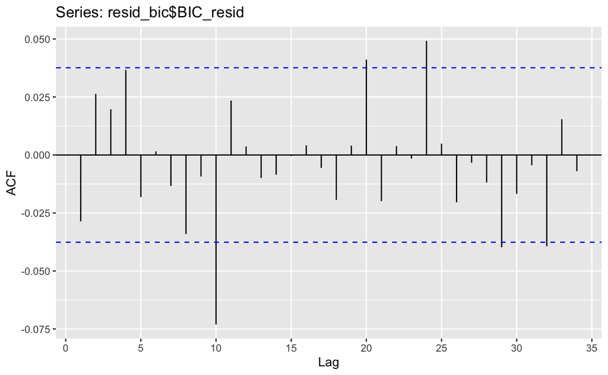

```r
ggAcf(resid_bic$BIC_resid)
```

Como forma de melhorar as propriedades dos modelos apresentados acima, utilizaremos duas variáveis consideradas relevantes na literatura economica, a expectativa de inflação e atividade representada pela mediana das projeções dos principais economistas de mercado para estas variáveis.

Abaixo plotaremos essas variáveis:

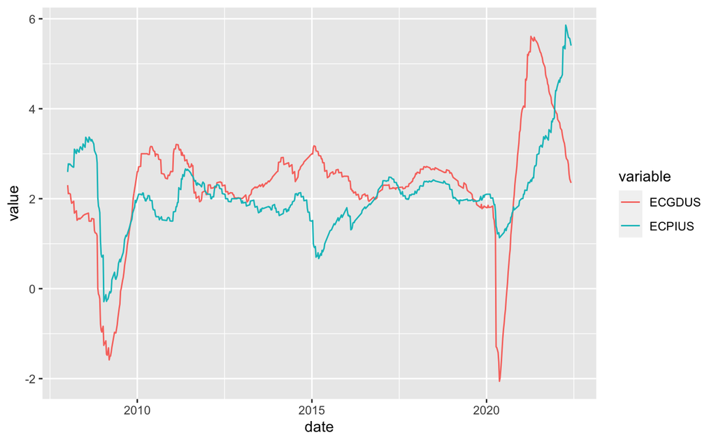

Novamente notamos que as variáveis são não estacionárias, então aplicaremos a primeira diferença nestas para conseguirmos utilizar na modelagem.

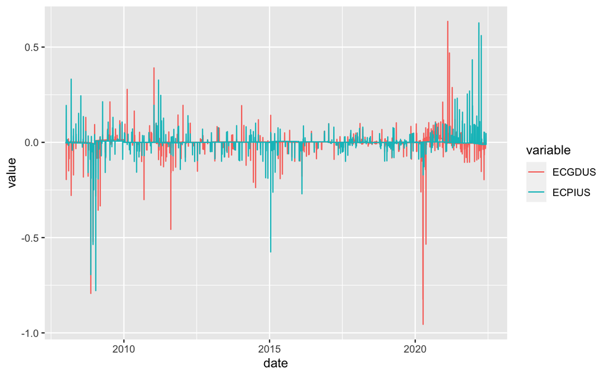

```r
summary(auto_arimax)
```

```
Series: all_data %>% select(USGG10YR_diff) %>% as.ts()
Regression with ARIMA(1,0,2) errors

Coefficients:
         ar1      ma1     ma2  ECGDUS  ECPIUS
      0.4101  -0.4859  0.1235  0.0894  0.1805
s.e.  0.2255   0.2240  0.0389  0.0839  0.0985

sigma^2 = 0.01361:  log likelihood = 551.09
AIC=-1090.18   AICc=-1090.07   BIC=-1062.44

Training set error measures:
                      ME      RMSE        MAE      MPE     MAPE      MASE         ACF1
Training set -0.00227335 0.1162759 0.08921116 106.7635 132.3824 0.6775714 0.0003826206
```

```r
shapiro.test(auto_arimax$residuals)
```

```
    Shapiro-Wilk normality test

data:  auto_arimax$residuals
W = 0.98677, p-value = 2.594e-06
```

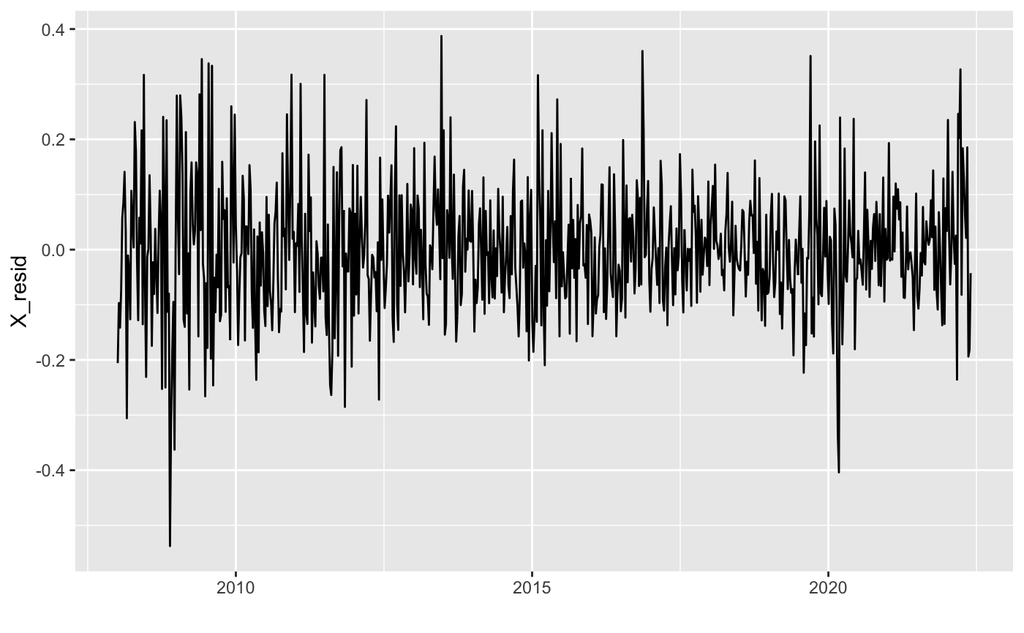

```r
ggplot(resid_x, aes(x=date, y=X_resid)) + geom_line() + xlab("")
```

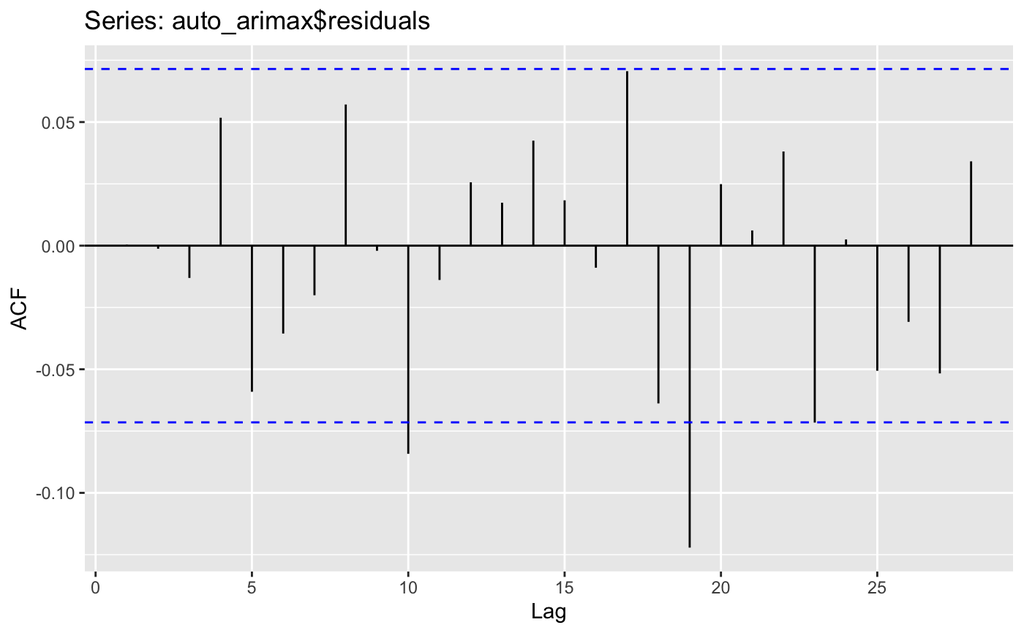

```r
ggAcf(auto_arimax$residuals)
```